# ZED Raport z analizy danych

Piotr Chojnacki 100743

2 sierpnia 2016

## Podsumowanie:

Celem tego projektu jest analiza danych z Protein Data Bank [PDB](http://www.rcsb.org/pdb/home/home.do) przy użyciu funkcjonalności języka R. Początko dane składają się z 795 kolumn i 40309 wierszy. Po odfiltrowaniu niepożądanych danych dane składają się z 795 kolumn i 39419 wierszy. Następnie pozostawiamy unikalne pary wartości (pdb_code, res_name), łącznie 13894 wierszy. W dalszym punkcie dane zostały podsumowane.

Następnie wykorzystano [zbiór treningowy](http://www.cs.put.poznan.pl/dbrzezinski/teaching/zed/zed_projekt_2015-2016_dane.7z).

## Kod wyliczający wykorzystane biblioteki:

```r
library(knitr)
library(tidyr)
library(magrittr)
library(dplyr)
library(ggplot2)
library(ggExtra)
library(corrplot)
library(MASS)
library(RColorBrewer)
library(reshape2)
library(purrr)
library(caret)
```

## Kod zapewniający powtarzalność wyników przy każdym uruchomieniu raportu na tych samych danych:

```r
set.seed(100743)
```

## Kod pozwalający wczytać dane z pliku:

```r
data <- read.table("all_summary.txt",
                    header = TRUE,
                    sep = ';',
                    na.strings = c("n/a", "nan", "NA", "NaN"))
```

Kod określający liczbę kolumn i wierszy:

```r
data_columns <- ncol(data)
data_rows <- nrow(data)
```

Otrzymujemy liczbe kolumn: 795 oraz liczbę wierszy: 40309.

## Kod usuwający z danych wiersze posiadające wartość zmiennej res_name równą: “DA”,“DC”,“DT”, “DU”, “DG”, “DI”,“UNK”, “UNX”, “UNL”, “PR”, “PD”, “Y1”, “EU”, “N”, “15P”, “UQ”, “PX4” lub “NAN”:

Tworzymy wektor z niechcianymi wartościami:

```r
to_delete <- c("DA","DC","DT", "DU", "DG", "DI","UNK", "UNX", "UNL", "PR", "PD", "Y1", "EU", "N", "15P", "UQ", "PX4","NAN")
```

Filtrujemy dane po kolumnie res_name, filtrując dodatkowo nulle:

```r
cleaned_data <- filter(data, !is.na(res_name), !res_name %in% to_delete)
```

Po oczyszczeniu danych z niepotrzebnych rekordów otrzymujemy liczbę kolumn: 795 oraz liczbę wierszy: 39419.

## Kod pozostawiający tylko unikatowe pary wartości (pdb_code, res_name):

```r
unique_data <- cleaned_data %>% distinct(pdb_code, res_name, .keep_all=TRUE)
```

W wyniku tej operacji pozostało nam 13894 wierszy.

## Krótkie podsumowanie wartości w każdej kolumnie:

```r
data_summary <- summary(unique_data)
kable(data_summary)
```

|  | title | pdb_code | res_name | res_id | chain_id | local_BAa | local_NPa | local_Ra | local_RGa | local_SRGa | local_CCSa | local_CCPa | local_ZOa | local_ZDa | local_ZD_minus_a | local_ZD_plus_a | local_res_atom_count | local_res_atom_non_h_count | local_res_atom_non_h_occupancy_sum | local_res_atom_non_h_electron_sum | local_res_atom_non_h_electron_occupancy_sum | local_res_atom_C_count | local_res_atom_N_count | local_res_atom_O_count | local_res_atom_S_count | dict_atom_non_h_count | dict_atom_non_h_electron_sum | dict_atom_C_count | dict_atom_N_count | … |
| --- | --- | --- | --- | --- | --- | --- | --- | --- | --- | --- | --- | --- | --- | --- | --- | --- | --- | --- | --- | --- | --- | --- | --- | --- | --- | --- | --- | --- | --- | --- |
|  | 110l BME 901 A: 1 | 3ag4 : 15 | SO4 :1183 | 301 : 425 | A :8490 | Mode:logical | Mode:logical | Mode:logical | Mode:logical | Mode:logical | Mode:logical | Mode:logical | Mode:logical | Mode:logical | Mode:logical | Mode:logical | Min. : 1.00 | Min. : 1.00 | Min. : 0.000 | Min. : 3.0 | Min. : 0.00 | Min. : 0.000 | Min. : 0.000 | Min. : 0.000 | Min. :0.0000 | Min. : 1.00 | Min. : 3.0 | Min. : 0.000 | Min. : 0.00 | … |
|  | 111l CL 173 A : 1 | 3abl : 14 | ZN : 849 | 1 : 416 | B :2866 | NA’s:13894 | NA’s:13894 | NA’s:13894 | NA’s:13894 | NA’s:13894 | NA’s:13894 | NA’s:13894 | NA’s:13894 | NA’s:13894 | NA’s:13894 | NA’s:13894 | 1st Qu.: 3.00 | 1st Qu.: 3.00 | 1st Qu.: 2.612 | 1st Qu.: 30.0 | 1st Qu.: 30.00 | 1st Qu.: 0.000 | 1st Qu.: 0.000 | 1st Qu.: 0.000 | 1st Qu.:0.0000 | 1st Qu.: 4.00 | 1st Qu.: 30.0 | 1st Qu.: 0.000 | 1st Qu.: 0.00 | … |
|  | 115l BME 901 A: 1 | 3abk : 13 | GOL : 778 | 501 : 414 | C : 775 | NA | NA | NA | NA | NA | NA | NA | NA | NA | NA | NA | Median : 8.00 | Median : 8.00 | Median : 7.000 | Median : 57.0 | Median : 54.00 | Median : 3.000 | Median : 0.000 | Median : 3.000 | Median :0.0000 | Median : 8.00 | Median : 61.0 | Median : 3.000 | Median : 0.00 | … |
|  | 115l CL 173 A : 1 | 2afh : 11 | CA : 661 | 401 : 392 | D : 546 | NA | NA | NA | NA | NA | NA | NA | NA | NA | NA | NA | Mean : 13.81 | Mean : 13.64 | Mean : 13.257 | Mean :103.1 | Mean : 99.83 | Mean : 7.458 | Mean : 1.374 | Mean : 3.882 | Mean :0.2246 | Mean : 13.96 | Mean :105.4 | Mean : 7.598 | Mean : 1.38 | … |
|  | 123l BME 901 A: 1 | 3a0b : 11 | MG : 402 | 201 : 300 | E : 218 | NA | NA | NA | NA | NA | NA | NA | NA | NA | NA | NA | 3rd Qu.: 21.00 | 3rd Qu.: 21.00 | 3rd Qu.: 20.000 | 3rd Qu.:147.0 | 3rd Qu.:143.00 | 3rd Qu.:10.000 | 3rd Qu.: 2.000 | 3rd Qu.: 5.000 | 3rd Qu.:0.0000 | 3rd Qu.: 21.00 | 3rd Qu.:154.0 | 3rd Qu.:10.000 | 3rd Qu.: 2.00 | … |
|  | 123l CL 173 A : 1 | 3g7f : 11 | CL : 400 | 500 : 225 | F : 139 | NA | NA | NA | NA | NA | NA | NA | NA | NA | NA | NA | Max. :178.00 | Max. :104.00 | Max. :104.000 | Max. :800.0 | Max. :800.00 | Max. :81.000 | Max. :15.000 | Max. :55.000 | Max. :9.0000 | Max. :128.00 | Max. :866.0 | Max. :81.000 | Max. :20.00 | … |
|  | (Other) :13888 | (Other):13819 | (Other):9621 | (Other):11722 | (Other): 860 | NA | NA | NA | NA | NA | NA | NA | NA | NA | NA | NA | NA | NA | NA | NA | NA | NA | NA | NA | NA | NA’s :19 | NA’s :19 | NA’s :19 | NA’s :19 | … |

## Sekcje sprawdzającą korelacje między zmiennymi; sekcja ta powinna zawierać jakąś formę graficznej prezentacji korelacji:

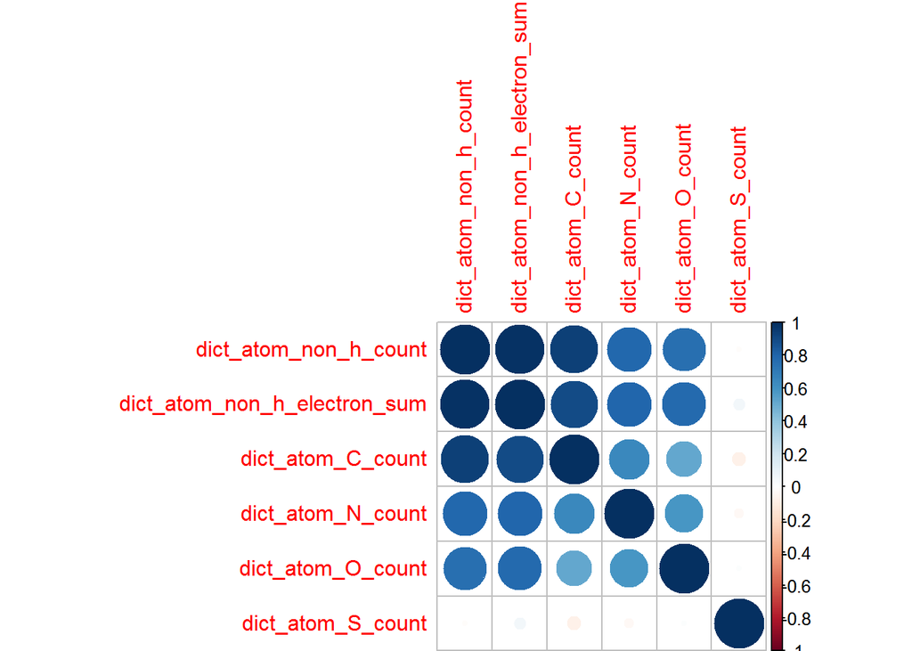

```r
selected_data <- unique_data %>% dplyr::select(dict_atom_non_h_count:dict_atom_S_count)
numeric_data <- na.omit(selected_data)
M <- cor(numeric_data) # get correlations
corrplot(M, method = "circle")
```

## Określenie ile przykładów ma każda z klas (res_name):

Grupujemy dane według wartości w kolumnie res_name:

```r
count_ud <- group_by(unique_data, res_name)
```

Sumujemy ilość przykładów danej klasy:

```r
summarize_ud <- summarize(count_ud, count = n())
```

Ustalamy kolejność malejąco po liczebności:

```r
arrange_ud <- arrange(summarize_ud, desc(count))
```

```r
kable(head(arrange_ud, n = 50))
```

[output not shown]

## Wykresy rozkładów liczby atomów (local_res_atom_non_h_count) i elektronów (local_res_atom_non_h_electron_sum):

Przekształcenia dla atomów:

```r
d <- dplyr::select(unique_data, local_res_atom_non_h_count)
sg <- group_by(d, local_res_atom_non_h_count)
ds <- summarize(sg, count = n())
da <- arrange(ds, desc(local_res_atom_non_h_count))
kable(ds)
```

| local_res_atom_non_h_count | count |
| --- | --- |
| 1 | 3344 |
| 2 | 18 |
| 3 | 119 |
| 4 | 724 |
| 5 | 1580 |
| 6 | 867 |
| 7 | 248 |
| 8 | 421 |
| 9 | 183 |
| 10 | 363 |
| 11 | 368 |
| 12 | 311 |
| 13 | 261 |
| 14 | 511 |
| 15 | 231 |
| 16 | 207 |
| 17 | 110 |
| 18 | 105 |
| 19 | 139 |
| 20 | 271 |
| 21 | 162 |
| 22 | 144 |
| 23 | 232 |
| 24 | 134 |
| 25 | 129 |
| 26 | 133 |
| 27 | 261 |
| 28 | 153 |
| 29 | 102 |
| 30 | 67 |

[output cut: 51 more lines]

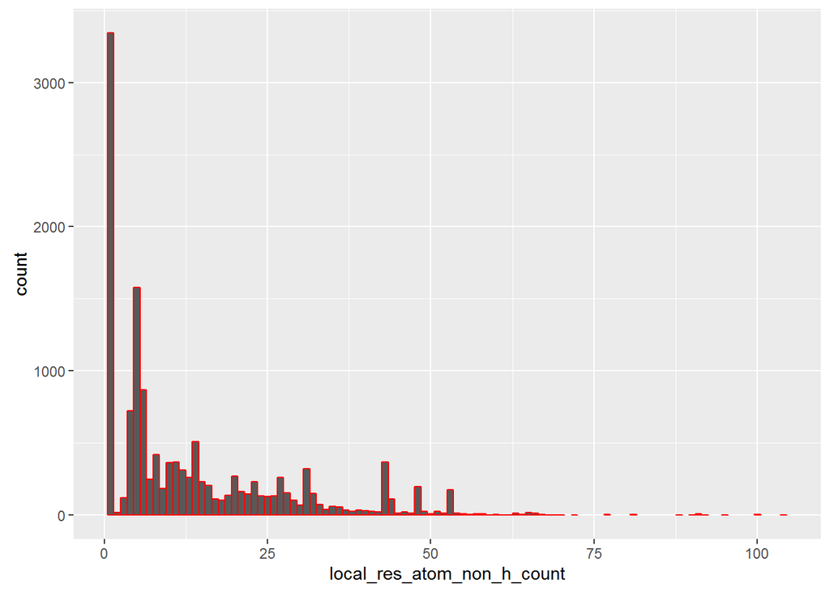

```r
ggplot(da, aes(x=local_res_atom_non_h_count, y = count)) + geom_bar(stat="identity", width=1, colour = "red")
```

Przekształcenia dla elektronów:

```r
d <- dplyr::select(unique_data, local_res_atom_non_h_electron_sum)
sg <- group_by(d, local_res_atom_non_h_electron_sum)
ds <- summarize(sg, count = n())
da <- arrange(ds, desc(local_res_atom_non_h_electron_sum))
kable(ds)
```

| local_res_atom_non_h_electron_sum | count |
| --- | --- |
| 3 | 2 |
| 6 | 1 |
| 7 | 4 |
| 12 | 402 |
| 16 | 5 |
| 17 | 400 |
| 19 | 119 |
| 20 | 693 |
| 21 | 5 |
| 22 | 35 |
| 23 | 2 |
| 24 | 1 |
| 25 | 186 |
| 26 | 198 |
| 27 | 70 |
| 28 | 556 |
| 29 | 132 |
| 30 | 863 |
| 31 | 29 |
| 32 | 34 |
| 33 | 17 |
| 34 | 11 |
| 35 | 32 |
| 36 | 117 |
| 37 | 6 |
| 38 | 11 |
| 39 | 32 |
| 40 | 35 |
| 41 | 7 |
| 42 | 793 |

[output cut: 371 more lines]

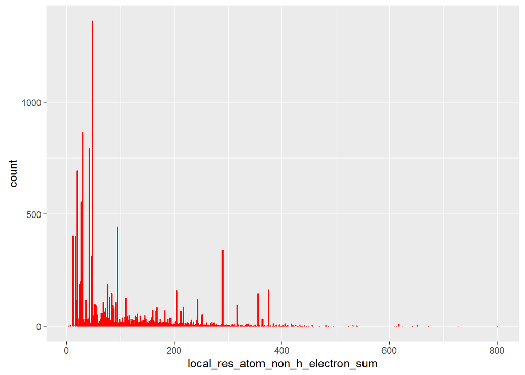

```r
ggplot(da, aes(x=local_res_atom_non_h_electron_sum, y = count)) + geom_bar(stat="identity", width=1, colour = "red")
```

## Próbę odtworzenia następującego wykresu (oś X - liczba elektronów, oś y - liczba atomów):

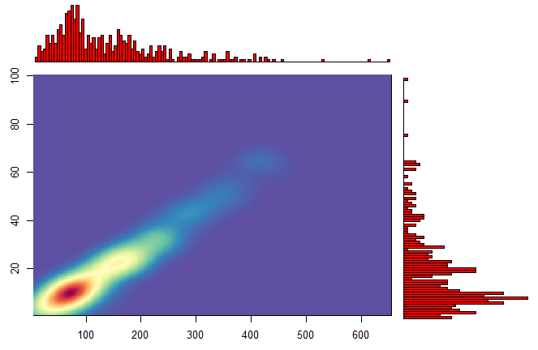

Pomocny kod do odtworzenia wykresu został zaczerpnięty z tej [strony](https://www.r-bloggers.com/5-ways-to-do-2d-histograms-in-r/).

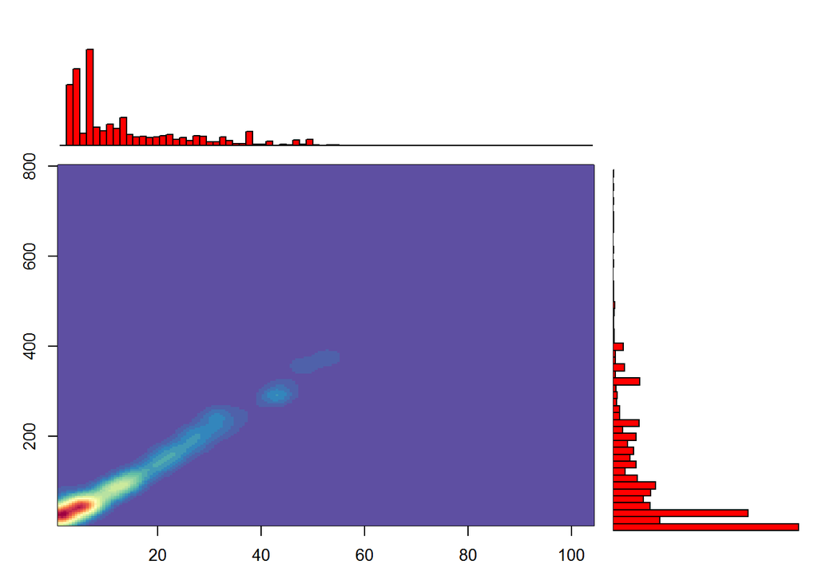

```r
h1 <- hist(unique_data$local_res_atom_non_h_electron_sum, breaks = 64, plot = F)
h2 <- hist(unique_data$local_res_atom_non_h_count, breaks = 64, plot = F)
top <- max(h1$counts, h2$counts)
k <- kde2d(unique_data$local_res_atom_non_h_count, unique_data$local_res_atom_non_h_electron_sum, n = 192)

rf <- colorRampPalette(rev(brewer.pal(11,'Spectral')))
r <- rf(32)

oldpar <- par()
par(mar=c(3,3,1,1))
layout(matrix(c(2,0,1,3),2,2,byrow=T),c(3,1), c(1,3))
image(k, col=r) #plot the image
par(mar=c(0,2,1,0))
barplot(h1$counts, axes=F, ylim=c(0, top), space=0, col='red')
par(mar=c(2,0,0.5,1))
barplot(h2$counts, axes=F, xlim=c(0, top), space=0, col='red', horiz=T)
```

## Tabela pokazująca 10 klas z największą niezgodnością liczby atomów (local_res_atom_non_h_count vs dict_atom_non_h_count) i tabelę pokazującą 10 klas z największą niezgodnością liczby elektronów (local_res_atom_non_h_electron_sum vs dict_atom_non_h_electron_sum;):

```r
n_atom <- dplyr::select(cleaned_data, res_name, local_res_atom_non_h_count, dict_atom_non_h_count)
n_atom <- mutate(n_atom, ld = dict_atom_non_h_count / local_res_atom_non_h_count, dl = local_res_atom_non_h_count / dict_atom_non_h_count)
n_atom <- group_by(n_atom, res_name)
n_atom <- summarize(n_atom, m = mean(ld), niezgodność = mean(dl))
n_atom <- arrange(n_atom, desc(m))
n_atom <- dplyr::select(n_atom, res_name, niezgodność)
kable(head(n =10, n_atom), caption = "Tabela pokazująca 10 klas z największą niezgodnością liczby atomów")
```

Tabela pokazująca 10 klas z największą niezgodnością liczby atomów

| res_name | niezgodność |
| --- | --- |
| QPT | 0.1538462 |
| PE3 | 0.3023256 |
| PEU | 0.1927711 |
| JEF | 0.1951220 |
| NKP | 0.2068966 |
| EMT | 0.2307692 |
| PC1 | 0.3724280 |
| MPG | 0.3169231 |
| MDS | 0.3225806 |
| SEK | 0.3333333 |

```r
n_el <- dplyr::select(cleaned_data, res_name, local_res_atom_non_h_electron_sum, dict_atom_non_h_electron_sum)
n_el <- mutate(n_el, ld = local_res_atom_non_h_electron_sum / dict_atom_non_h_electron_sum, dl = dict_atom_non_h_electron_sum / local_res_atom_non_h_electron_sum)
n_el <- group_by(n_el, res_name)
n_el <- summarize(n_el, m = mean(dl), niezgodność = mean(ld))
n_el <- arrange(n_el, desc(m))
n_el <- dplyr::select(n_el, res_name, niezgodność)
kable(head(n =10, n_el), caption = "Tabela pokazująca 10 klas z największą niezgodnością liczby elektronów")
```

Tabela pokazująca 10 klas z największą niezgodnością liczby elektronów

| res_name | niezgodność |
| --- | --- |
| NKP | 0.1827411 |
| PE3 | 0.3020833 |
| PEU | 0.1940433 |
| JEF | 0.2022472 |
| PC1 | 0.3800000 |
| 0QE | 0.2608696 |
| MPG | 0.3047712 |
| MDS | 0.3716814 |
| XPE | 0.5352564 |
| THF | 0.3777778 |

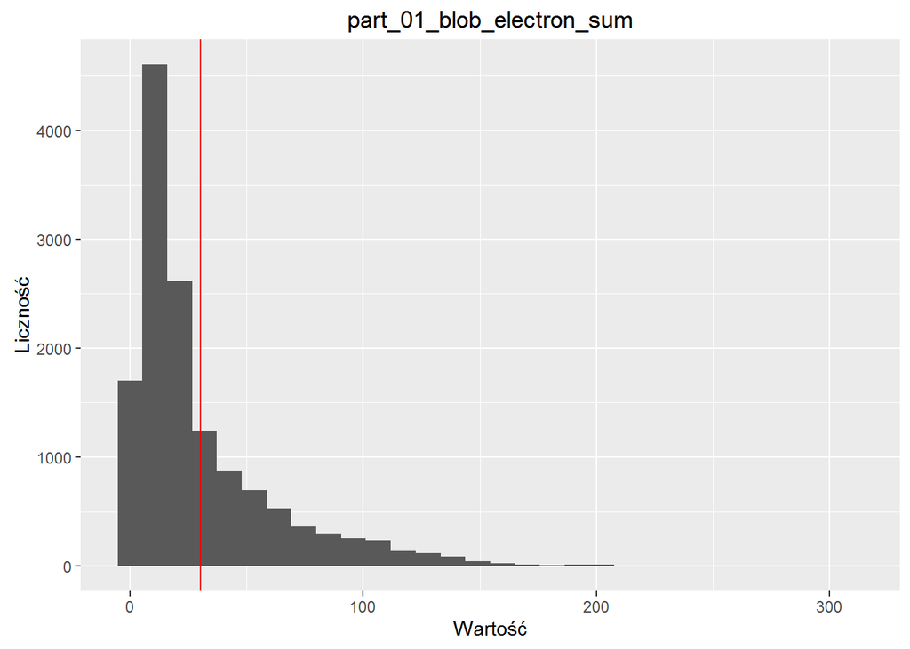

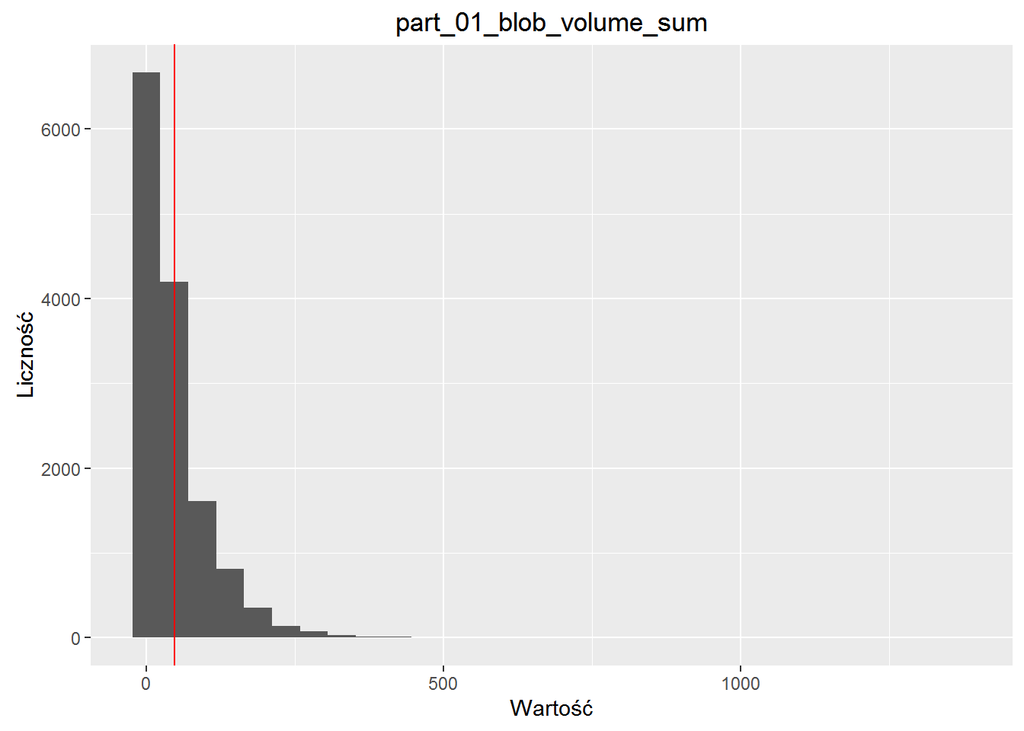

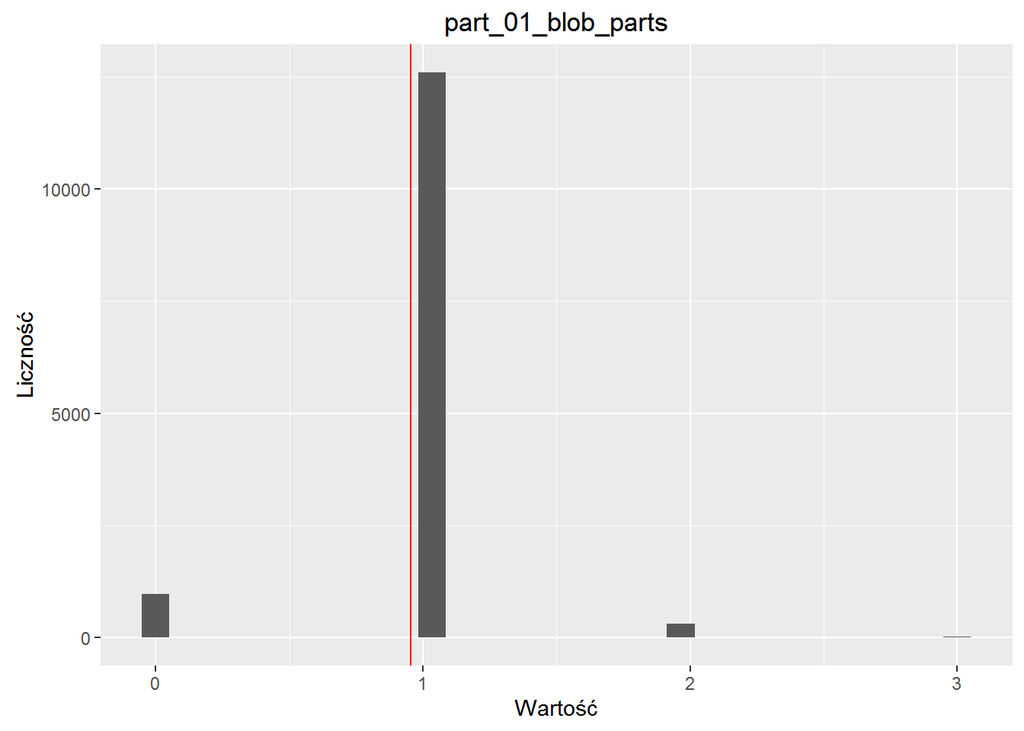

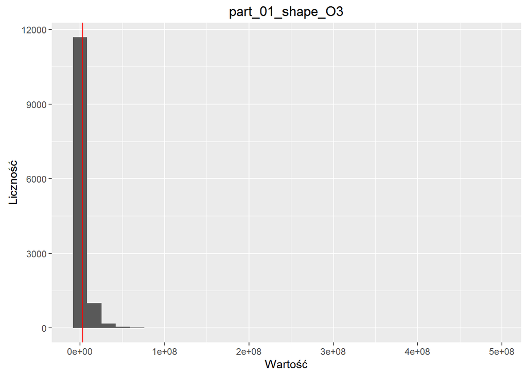

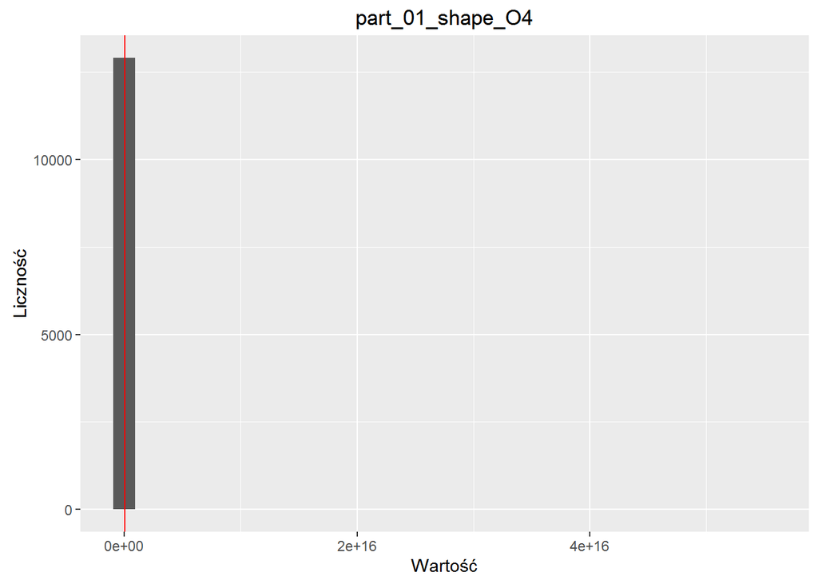

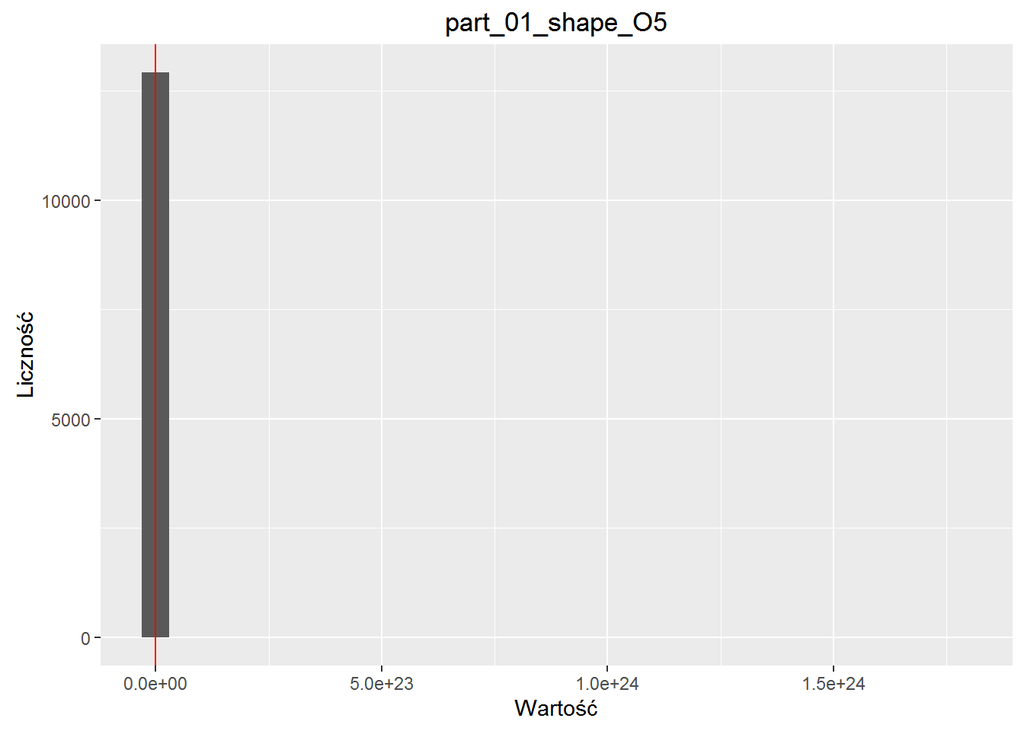

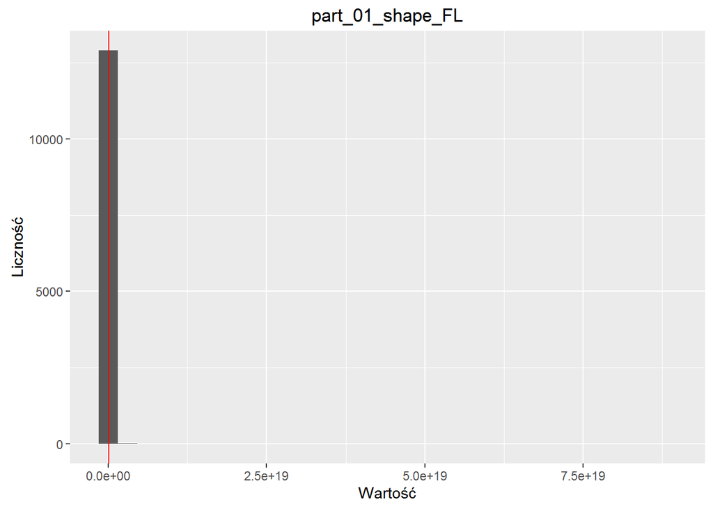

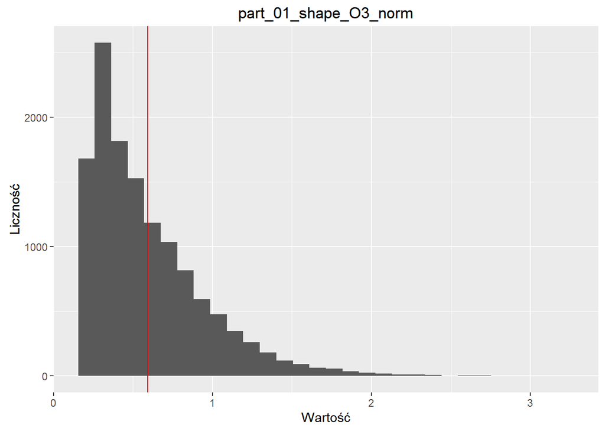

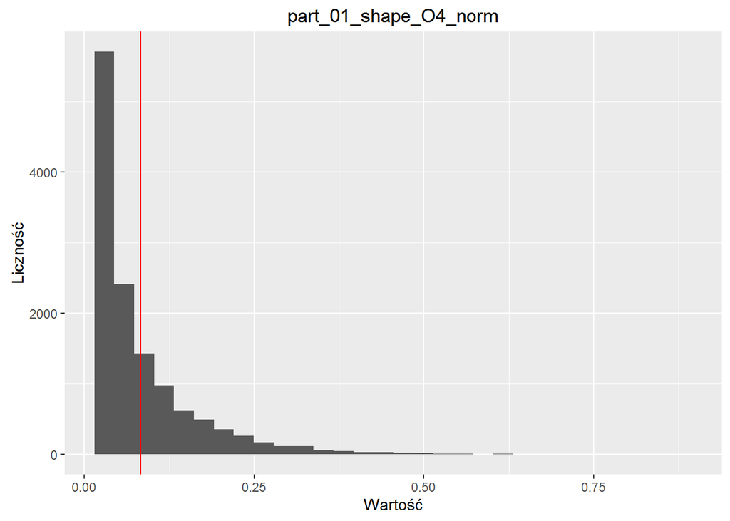

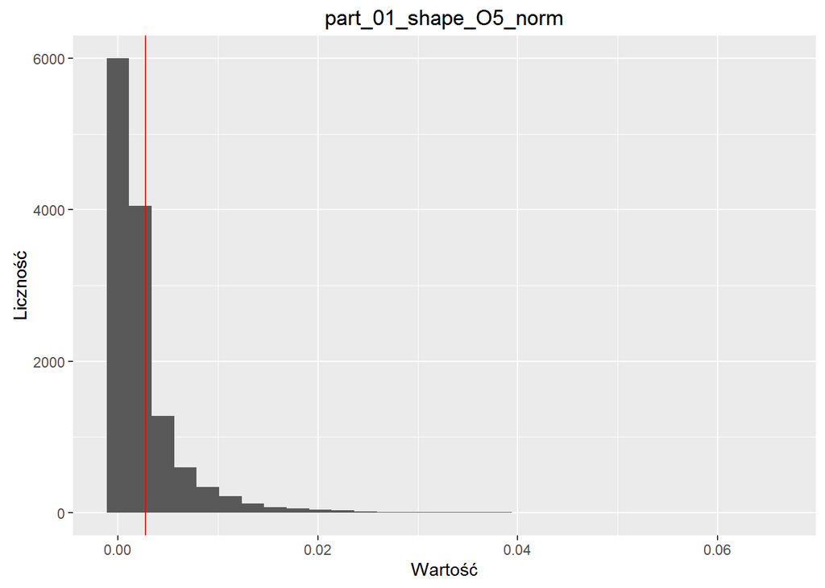

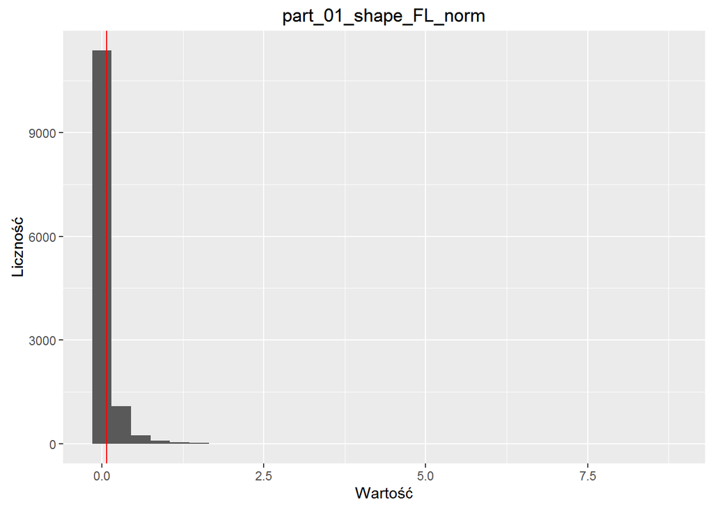

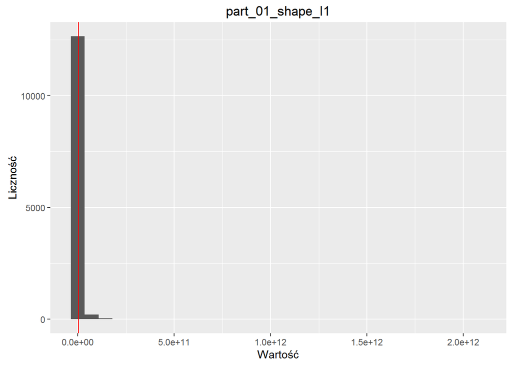

[57 more figures not shown]

```r
good_cols <- dplyr::select(unique_data, part_01_blob_electron_sum:part_01_density_sqrt_E3)

for (i in 1:ncol(good_cols)) {
         m <- colMeans(good_cols, na.rm = TRUE)
         plot <- ggplot(data=good_cols, aes(good_cols[i])) +
                  geom_histogram(bins = 30) +
                  geom_vline(xintercept = m[i], colour="red") +
                  ggtitle(colnames(good_cols[i])) +
                  ylab("Liczność") +
                  xlab("Wartość")
         print(plot)
}
```

## Sekcja sprawdzająca czy na podstawie wartości innych kolumn można przewidzieć liczbę elektronów i atomów oraz z jaką dokładnością można dokonać takiej predykcji; trafność regresji powinna zostać oszacowana na podstawie miar R^2 i RMSE:

Dla atomów:

```r
best_data <- cleaned_data[ , apply(cleaned_data, 2, function(x) !any(is.na(x)))]

names(best_data)
```

```
##   [1] "title"
##   [2] "pdb_code"
##   [3] "res_name"
##   [4] "res_id"
##   [5] "chain_id"
##   [6] "local_res_atom_count"
##   [7] "local_res_atom_non_h_count"
##   [8] "local_res_atom_non_h_occupancy_sum"
##   [9] "local_res_atom_non_h_electron_sum"
##  [10] "local_res_atom_non_h_electron_occupancy_sum"
##  [11] "local_res_atom_C_count"
##  [12] "local_res_atom_N_count"
##  [13] "local_res_atom_O_count"
##  [14] "local_res_atom_S_count"
##  [15] "part_00_blob_electron_sum"
```

[output cut: 87 more lines]

```r
best_data <- dplyr::select(best_data, local_res_atom_non_h_count:local_parts)

inTraining <- createDataPartition(best_data$local_res_atom_non_h_count, p = .75, list = FALSE)
training <- best_data[ inTraining,]
testing  <- best_data[-inTraining,]
fit <- train(local_res_atom_non_h_count ~ . , data = training, method = "lm")
gbmFit1 <- train(local_res_atom_non_h_count ~ ., data = training,
                 method = "lm",
                 verbose = FALSE)
kable(gbmFit1$results)
```

| intercept | RMSE | Rsquared | RMSESD | RsquaredSD |
| --- | --- | --- | --- | --- |
| TRUE | 0.378157 | 0.9993896 | 0.0069019 | 2.64e-05 |

Dla elektronów:

```r
best_data <- cleaned_data[ , apply(cleaned_data, 2, function(x) !any(is.na(x)))]

names(best_data)
```

```
##   [1] "title"
##   [2] "pdb_code"
##   [3] "res_name"
##   [4] "res_id"
##   [5] "chain_id"
##   [6] "local_res_atom_count"
##   [7] "local_res_atom_non_h_count"
##   [8] "local_res_atom_non_h_occupancy_sum"
##   [9] "local_res_atom_non_h_electron_sum"
##  [10] "local_res_atom_non_h_electron_occupancy_sum"
##  [11] "local_res_atom_C_count"
##  [12] "local_res_atom_N_count"
##  [13] "local_res_atom_O_count"
##  [14] "local_res_atom_S_count"
##  [15] "part_00_blob_electron_sum"
```

[output cut: 87 more lines]

```r
best_data <- dplyr::select(best_data, local_res_atom_non_h_count:local_parts)

inTraining <- createDataPartition(best_data$local_res_atom_non_h_electron_sum, p = .75, list = FALSE)
training <- best_data[ inTraining,]
testing  <- best_data[-inTraining,]
fit <- train(local_res_atom_non_h_count ~ . , data = training, method = "lm")
gbmFit1 <- train(local_res_atom_non_h_electron_sum ~ ., data = training,
                 method = "lm",
                 verbose = FALSE)
kable(gbmFit1$results)
```

| intercept | RMSE | Rsquared | RMSESD | RsquaredSD |
| --- | --- | --- | --- | --- |
| TRUE | 4.204073 | 0.9983032 | 0.1272771 | 0.0001066 |

```r
best_data <- cleaned_data %>% dplyr::select(res_name, local_res_atom_non_h_count:local_parts)
bd2 <- transform(best_data,res_name_id=as.numeric(factor(res_name)))
bd2 <- subset(bd2, select = -c(res_name))

bd2 <- na.omit(bd2)

inTraining <- createDataPartition(bd2$res_name_id, p = .75, list = FALSE)
training <- bd2[ inTraining,]
testing  <- bd2[-inTraining,]
fit <- train(res_name_id ~ . , data = training, method = "lm")
gbmFit1 <- train(local_res_atom_non_h_electron_sum ~ ., data = training,
                 method = "lm",
                 verbose = FALSE)
kable(gbmFit1$results)
```

| intercept | RMSE | Rsquared | RMSESD | RsquaredSD |
| --- | --- | --- | --- | --- |
| TRUE | 10.11162 | 0.9796721 | 16.44133 | 0.0522863 |